# F3. Kontinuerliga slumpvariabler

Author

Ullrika Sahlin

# (fort F2) Varians

Låt $\mu$ vara väntevärdet för slumpvariabeln $X$

Variansen beskriver spridningen runt väntevärdet. Mer specifikt är variansen det föräntade kvadratiska avståndet från väntevärdet.

$V(X) = E((X-E(X))^2)$

eller

$V(X) = E((X-\mu)^2)$

**Note**

Orsaken till att man kvadrerar avstånden är att det kommer vara både negativa och positiva avstånd, och att de kan “ta ut varandra” om man summerar direkt.

Standardavvikelsen är $\sqrt{V(X)}$ och får ner spridningsmåttet på samma skala som slumpvariabeln $X$.

# (fort F2) Variansen för en diskret slumpvariabel

$X$ är en diskret slumpvariabel

$V(X)=\sum_{\text{alla x}} (x-\mu)^2P(X=x)$

**Exempel: Tärningskast**

Låt $X=$ “antal prickar

Vi har tidigare visat att $E(X)=3.5$

$$\begin{split} & V(X)=\sum_{x=1}^6(x-3.5)^2\cdot \frac{1}{6} = \\ & \frac{1}{6} ((1-3.5)^2+(2-3.5)^2+(3-3.5)^2+(4-3.5)^2+(5-3.5)^2+(6-3.5)^2) = \\ & \frac{1}{6} ((-2.5)^2 + (-1.5)^2+ (-0.5)^2+ (0.5)^2+ (1.5)^2+ (2.5)^2) = \frac{17.5}{6} \end{split}$$

**(fort F2) Tentauppgift på väntevärde**

På en speciell vägsträcka gäller att slumpvariabeln $X = \text{antal olyckor på en vecka}$ har följande fördelning

| Utfall (x) | 0 | 1 | 2 | 3 |
| --- | --- | --- | --- | --- |
| $P(X = x)$ | 0.70 | 0.20 | 0.06 | 0.04 |

### Beräkna det förväntande antalet olyckor under en vecka

$$\begin{split} & E(X) = \sum_{x=0}^3 x\cdot P(X=x) = \\ & 0\cdot 0.70 + 1 \cdot 0.20 + 2\cdot 0.06+ 3\cdot 0.04
= 0.44 \end{split}$$

> Symbolen $\therefore$ står för *därför är min slutsats att*

### Vad är variansen? (var inte en tentauppgift)

$$\begin{split} & V(X)=\sum_{x=0}^3 (x-\mu)^2\cdot P(X=x) =\sum_{x=0}^3 (x-0.44)^2\cdot P(X=x)=\\ & (0-0.44)^2\cdot 0.70 + (1-0.44)^2 \cdot 0.20 + (2-0.44)^2\cdot 0.06+ (3-0.44)^2\cdot 0.04 =\\ & 0.6064 \end{split}$$

# (fort F2) Sannolikhets och fördelningsfunktion diskreta slumpvariabler

Para ihop $f(x)$ med $F(X)$

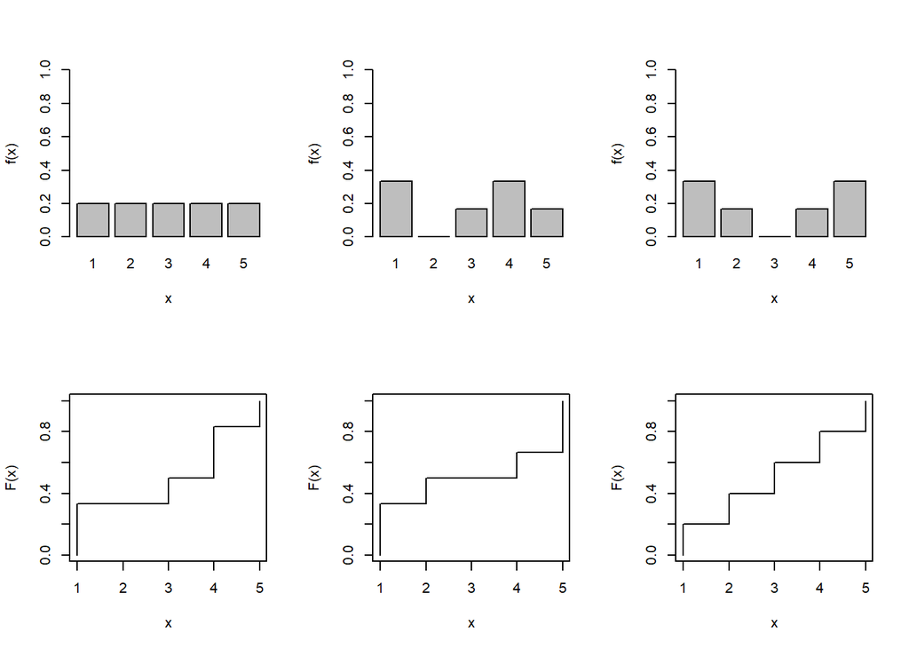

**Exempel. Poissonfördelningen**

$X=\text{"antal spam per timme"}$

Modell: $X \sim Po(\lambda_X)$ där $\lambda_X=0.5$

Vad är sannolikheten att få minst 6 spam på ett dygn?

Det första vi behöver göra är att omvandla modellens intensitets-parameter så den ger antal över rätt tidsenhet. Från per timme till per dygn.

1 spam per timme motsvarar 24 spam per dygn

$Y=\text{antal spam per dygn}$

Modell: $Y \sim Po(\lambda_Y)$ där $\lambda_Y=24\cdot 0.5 = 12$

$$\begin{split} & P(Y\geq 6) = P(Y\geq 6) = \\ & 1-P(Y\leq 5) = 1 - F_Y(5) = \\ & 1- 0.0203 = 0.9797 \end{split}$$

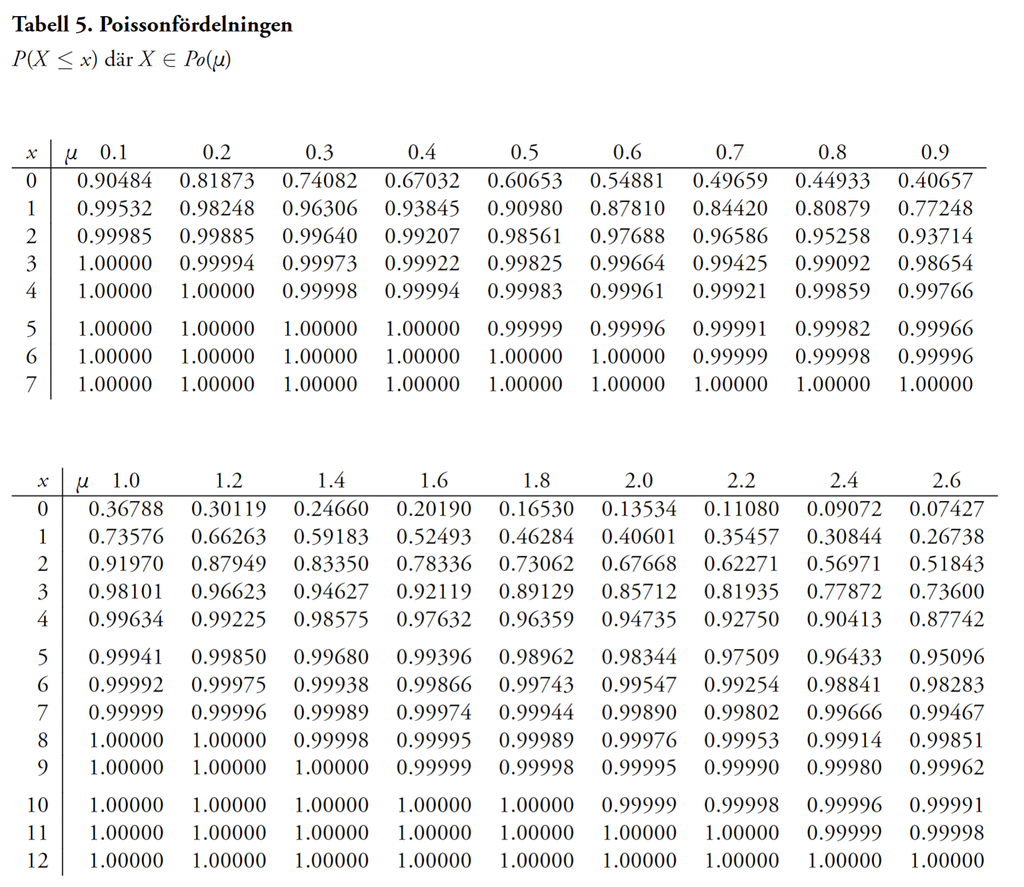

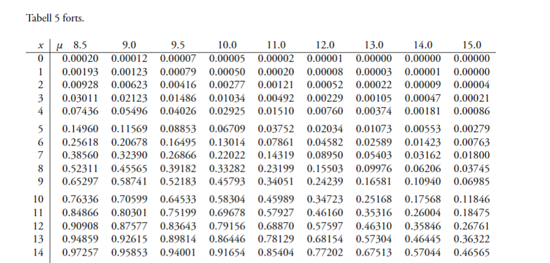

Alternativt kan man beräkna värdet på fördelningsfunktionen direkt

# (fort F2) Väntevärde för en Poissonfördelning

Överkurs

$X \sim Po(\lambda)$ and $f(x) = \frac{\lambda^xe^{-\lambda}}{x!}$

$$\begin{split} & E(X) = \sum_{x=0}^{\infty}x\cdot f(x) = \sum_{x=1}^{\infty}x\cdot f(x) = \\ &
\sum_{x=1}^{\infty}x\cdot \frac{\lambda^xe^{-\lambda}}{x!} = \sum_{x=1}^{\infty}\frac{\lambda^xe^{-\lambda}}{(x-1)!} = \\& e^{-\lambda} \sum_{x=1}^{\infty}\frac{\lambda^x}{(x-1)!} = \\ &
\lambda \cdot e^{-\lambda} \sum_{x=1}^{\infty}\frac{\lambda^{x-1}}{(x-1)!} = \\ &
\lambda \cdot e^{-\lambda} \sum_{x=0}^{\infty}\frac{\lambda^x}{x!} = \lambda\cdot e^{-\lambda}\cdot e^{\lambda} = \lambda \end{split}$$

> I näst sista steget använde vi det matematiska resultatet att $\sum_{x=0}^{\infty}\frac{\lambda^x}{x!} = e^{\lambda}$

# Kontinuerliga slumpvariabler

- En kontinuerlig slumpvariabel $X$ antar oändligt många värden. Det betyder att

$$P(X =x) = 0$$

- Istället studerar man sannolikheten för intervall, t.ex. intervallet $[a,b]$:

$$P(a \leq X \leq b)$$

- Fördelning av en kontinuerlig s.v $X$ kan beskrivas med hjälp av en täthetsfunktion (*på engelska: probability density function, PDF*)

$$f_X(x) \geq 0$$

# Täthetsfunktion för en kontinuerlig s.v.

**Exempel. Likformig fördelning**

*På engelska: Uniform distribution*

$$f(x) = \left\{ \begin{array}{lr}
\frac{1}{b-a} & a \leq x \leq b\\
0 & \text{annars}
\end{array}\right.$$

> Eftersom täthetsfunktionen ser ut som en rektangen kallas denna fördelning även **rektangelfördelning**

En likformig fördelning lämpar sig för s.v. som antar värden i ett intervall med lika stor sannolikhet.

**Exempel. Exponentialfördelning**

$$f(x) = \left\{ \begin{array}{lr}
\lambda\cdot e^{-\lambda x} & x \geq 0\\
0 & \text{annars}
\end{array}\right.$$

Exponentialfördelning antar icke-negativa värden $x \geq 0$.

Det är en lämplig fördelning för att beskriva tiden det tar till en händelse, t.ex. väntetid på en buss eller att få komma in till doktorn.

**Exempel. Normalfördelning**

$f(x) = \frac{1}{\sigma \sqrt{2\pi}}e^{-\frac{(x-\mu)^2}{2\sigma^2}}$ där $-\infty < x < \infty$

> En normalfördelning har två parametrar, $\mu$ och $\sigma^2$ som också är fördelningens väntevärde och varians

# Fördelningsfunktion för en kontinuerlig s.v.

- Sannolikhet motsvarar en area under täthetsfunktionen
- Fördelningsfunktionen är arean upp till utfallet $x$

$$F(x)=\int_{-\infty}^{x} f(v)dv$$

- Totala arean under täthesfunktionen är alltid 1

$$\int_{-\infty}^{\infty} f(x)dx$$

- $P(X < x) = P(X\leq x)$ för kontinuerliga s.v. (inte för diskreta)

**Exempel. Likformig fördelning**

Slumpvariabeln $X$ är likformigt fördelat i intervallet 0 till 10.

Då vet vi att täthetsfunktionen är
$$f(x) = \left\{ \begin{array}{lr}
\frac{1}{10} & 0 \leq x \leq 10\\
0 & \text{annars}
\end{array}\right.$$

Vad är sannolikheten att $X$ är mindre eller lika med 7?

$$\begin{split} & P(X \leq 7) = F(7) = \int_{-\infty}^7 f(x)dx = \\ & \int_0^7 \frac{1}{10}dx = [\frac{x}{10}]_{x=0}^{7} = \\ & \frac{7}{10} - \frac{0}{10} = \frac{7}{10} \end{split}$$

**Exempel. Exponentialfördelning**

Slumpvariabeln $X$ är exponentialfördelad med parametern $\lambda = \frac{3}{2}$

Vi vet att
$$f(x) = \left\{ \begin{array}{lr}
\lambda\cdot e^{-\lambda x} & x \geq 0\\
0 & \text{annars}
\end{array}\right.$$

Vad är sannolikheten att $X$ är mindre eller lika med 2?

$$\begin{split} & P(X \leq 2) = F(2) = \int_{-\infty}^2 f(x)dx = \\ & \int_{-\infty}^2 \lambda\cdot e^{-\lambda x}dx =\int_{0}^2 \frac{3}{2}\cdot e^{-\frac{3}{2} x}dx = \\ & [-e^{-\frac{3}{2} x}]_{x=0}^{2} = -e^{-\frac{3}{2}\cdot 2} - -e^{-\frac{3}{2} \cdot 0} = \\ &
-e^{-3} + 1 = 1 - e^{-3} \end{split}$$

## Fördelningsfunktion för en exponentialfördelning

Fördelningsfunktionen för en exponentialfördelad slumpvariabel är

$$F(x) = 1 - e^{-\lambda x}$$

# Komplementhändelse för en kontinuerlig s.v.

$P(X \geq x) = 1 - P(X < x) \underbrace{ =}_{P(X=x)=0} 1 - P(X \leq x)$

# Sannolikhet över ett intervall

$P(a < X \leq b) = P(X \leq b) - P(X \leq a)$

**Exempel: Intervall**

$P(-2 < X \leq 1)$

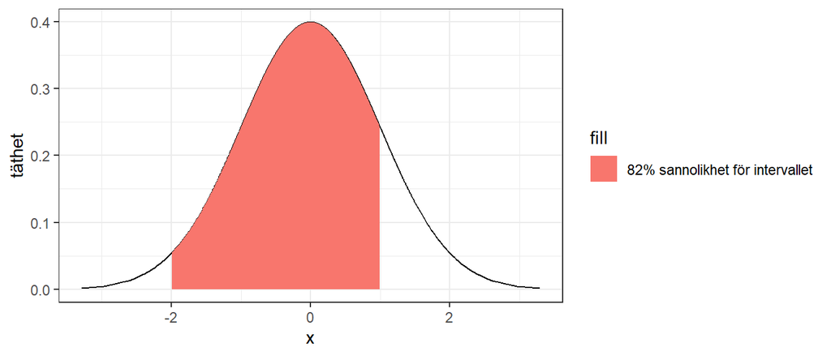

# Väntevärde och varians för en kontinuerlig s.v.

$X$ är en kontinuerlig slumpvariabel

$\mu= E(X) = \int_{-\infty}^{\infty} xf(x)dx$

$\sigma^2 = V(X) = \int_{-\infty}^{\infty} (x-\mu)^2f(x)dx$

**Exempel: Exponentialfördelning**

$X \sim Exp(\lambda)$

$E(X) = \frac{1}{\lambda}$

$V(X) = \frac{1}{\lambda^2}$

[Exponential distribution on wiki](https://en.wikipedia.org/wiki/Exponential_distribution)

# Diskreta och kontinuerliga s.v.

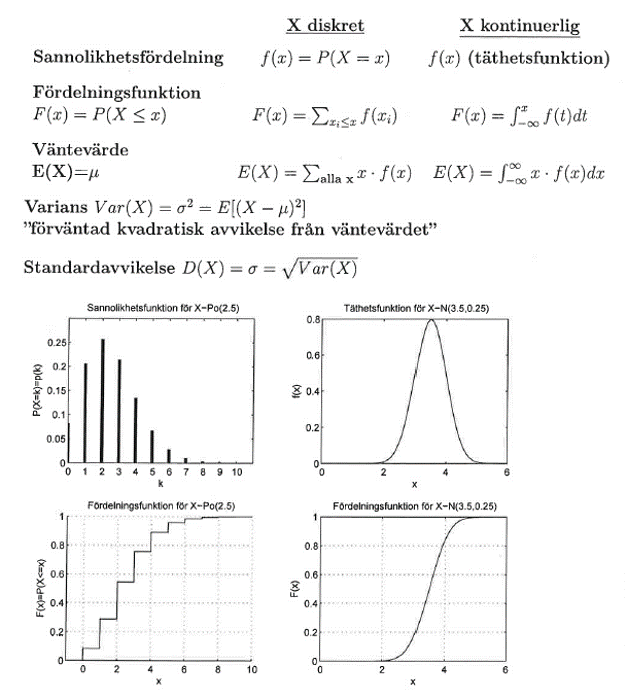

# Normalfördelning

- Normalfördelningen är otroligt användbar och uppkommer ofta man vill beskriva olika naturliga fenomen
- Normalfördelningen är en bra beskrivning av fördelningen för summor av oberoende och likafördelade slumpvariabler
- Vi kommer lägga ner mycket tid på normalfördelningen i denna kurs
- Det finns en del trick för att ta fram ett värde på fördelningsfunktionen för vilka parametervärden som helst

## Täthetsfunktion för normalfördelning

$X \sim N(\mu,\sigma)$

**standardavvikelse eller varians**

Vissa textböcker och program använder varians i formeln $N(\mu,\sigma^2)$

- Täthetsfunktionen för en normalfördelning ser ut som en kyrk-klocka
- Normalfördelningen är symmetrisk

$F(x) = 1 - F(-x)$

- Typvärde, median och väntevärde sammanfaller i en normalfördelning

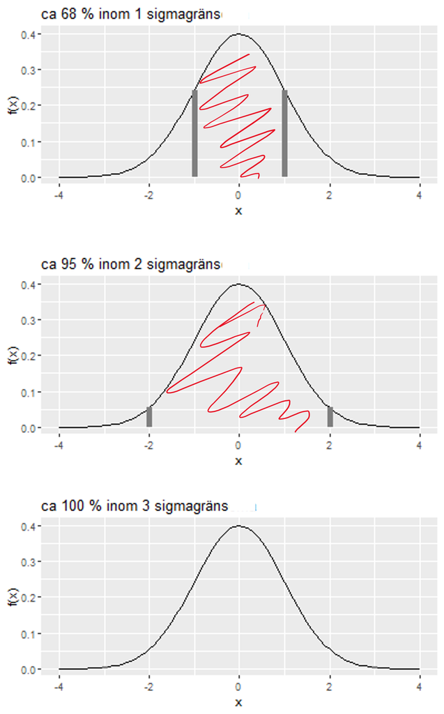

## Fördelningsfunktion för en normalfördelning

$X \sim N(\mu,\sigma)$

$$\begin{split} P(X \leq 0.1) & = F(0.1) = \int_{-\infty}^{0.1}f(x)dx = \\ & \int_{-\infty}^{0.1}\frac{1}{\sigma \sqrt{2\pi}}e^{-\frac{(x-\mu)^2}{2\sigma^2}}dx \end{split}$$

Låt oss anta att $\mu=0$ och $\sigma=1$

$$=\int_{-\infty}^{0.1}\frac{1}{\sqrt{2\pi}}e^{-x^2}dx = \dots\text{går att lösa men svårt}$$

## Fördelningsfunktion för en normalfördelning - tabell

Istället för att beräkna integralen kan vi använda

- tabeller
- miniräknare/datorprogram

I de fall vi har en tabell - hur gör man för alla möjliga värden på väntevärdet $\mu$ och variansen $\sigma^2$?

Lösningen är att standardisera fördelningen

# Standardiserad normalfördelning

$X \sim N(3,4)$

Skapa en ny s.v. $Z = \frac{X-3}{4}$

Man kan visa att $Z \sim N(0,1)$, en standardiserad normalfördelning.

Följande gäller $X = 3 + 4\cdot Z$

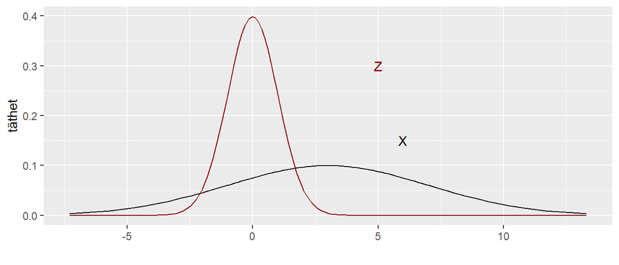

> Fördelningsfunktionen för en standardiserad normalfördelning kan betecknas $\Phi(x)$ och finns i tabell

$$\begin{split} & P(X \leq 4) = P(\frac{X-3}{4} \leq \frac{4-3}{4}) = \\ &
P(Z \leq 0.25) = \Phi(0.25) \underbrace{= 0.5987}_{\text{ur tabell}} \end{split}$$

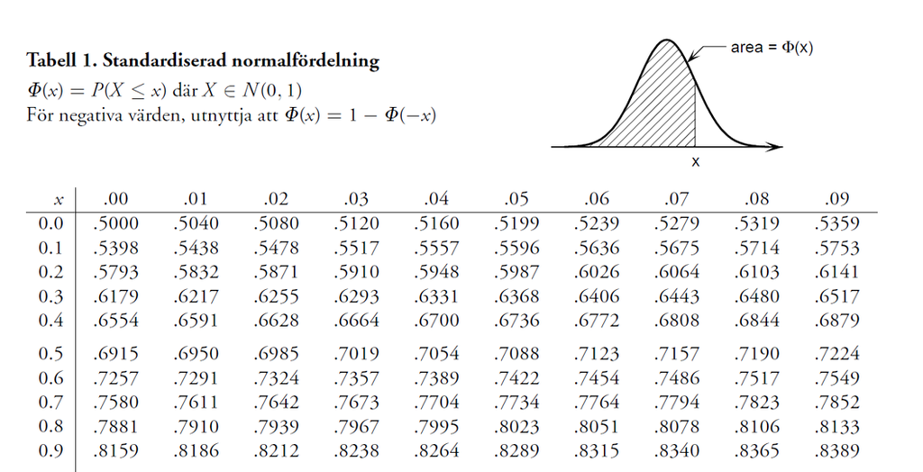

## Standardiserad normalfördelning och normalfördelning

Låt $Z \sim N(0,1)$

Då är $X = \mu + \sigma \cdot Z$ också normalfördelad med väntevärde $\mu$ och varians $\sigma^2$, d.v.s.
$$X \sim N(\mu,\sigma)$$

**Exempel. Normalfördelning**

Låt $X \sim N(5,2)$

$$\begin{split} & P(X \geq 0) = 1 - P(X < 0) = 1 - P(X \leq 0) = \\ & 1 - P(\frac{X-5}{2} \leq \frac{0-5}{2}) = 1 - \Phi(\frac{-5}{2}) = \\ & 1 - (1-\Phi(\frac{5}{2})) \end{split}$$

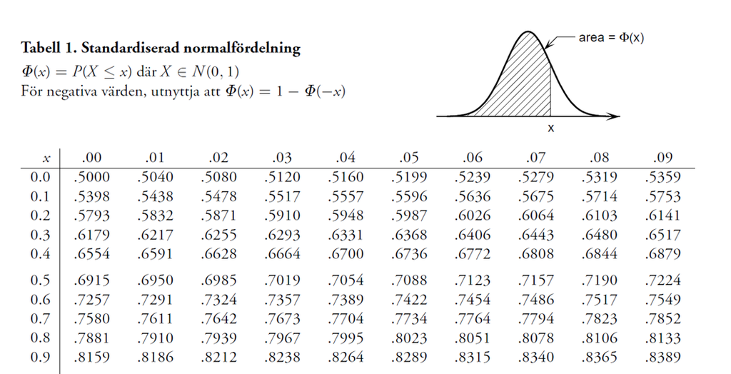

**Tentauppgift**

Vikten hos en alpin skidåkare med utrustning anses normalfördelad med väntevärde 80 kg och varians 36 kg^2. Skidåkaren Kim åker ensam i karbinen. Vad är sannolikheten att hens vikt överstiger 90 kg?

Låt $X = \text{"vikt i kg"}$

Modell: $X \sim N(80,6)$

$$\begin{split} & P(X > 90) = 1 - P(X \leq 90) = \\ & 1 - P(\frac{X-80}{6} \leq \frac{90-80}{6}) = 1 - \Phi(\frac{10}{6}) \end{split}$$

# Kvantil

En kvantil delar en sannolikhetsfördelning i två delar.

$$P(X \leq x_{.98}) = 0.98$$

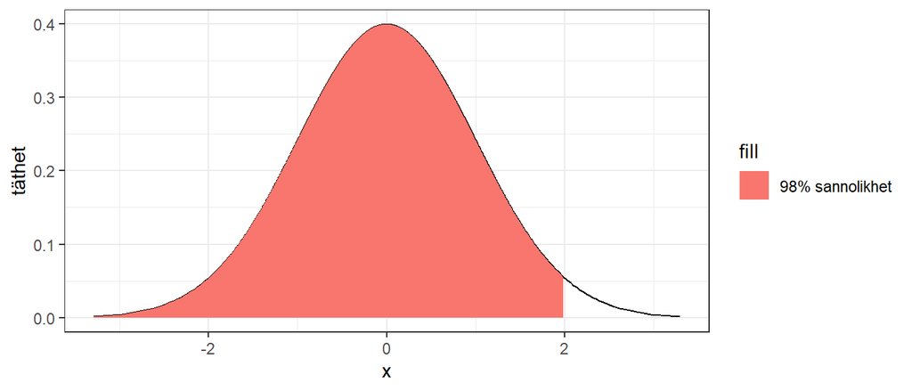

eller

$$P(X > \lambda_{.02}) = 0.02$$

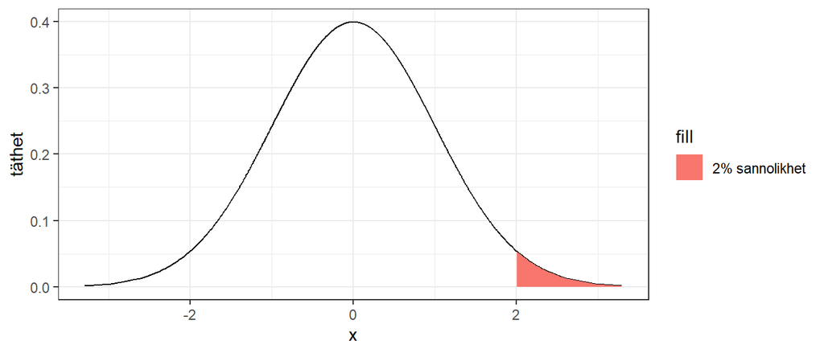

## Exempel på kvantiler

- **Median** – den kvantil som delar in fördelningen i två delar, med 50% sannolikhet i varje
- **Kvartiler** – de kvantiler som delar in fördelningen i fyra delar som har lika stor sannolikhet:
  - Första kvartilen (Q1)
  - Andra kvartilen = Medianen
  - Tredje kvartilen (Q3)
- **Percentil** – den p:te percentilen är det värde för en slumpvariabel som är högre än p% av alla möjliga värden

## Kvantiler illustrerade med en fördelningsfunktion

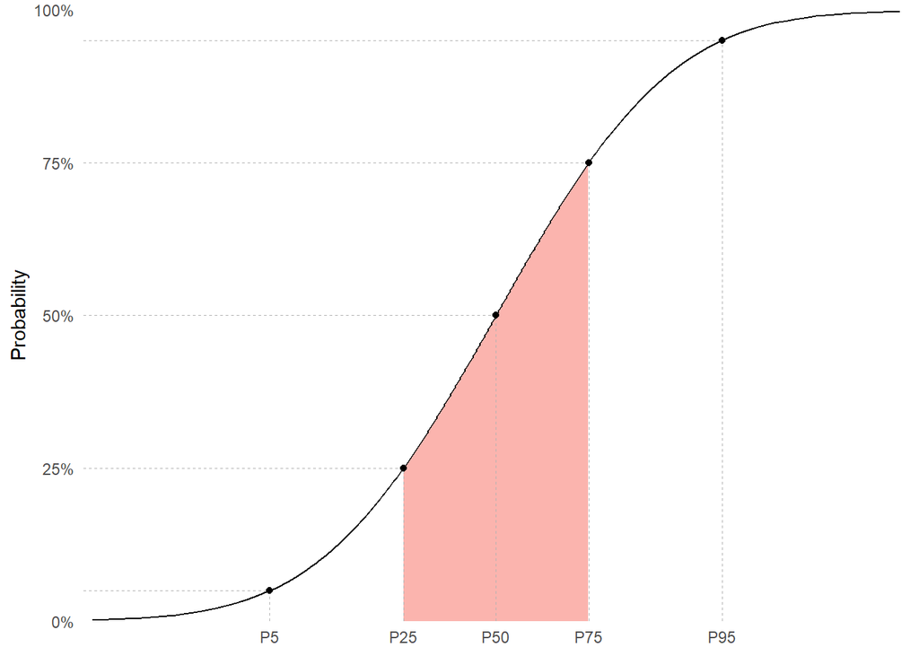

## Kvantiler illustrerade med en täthetsfunktion

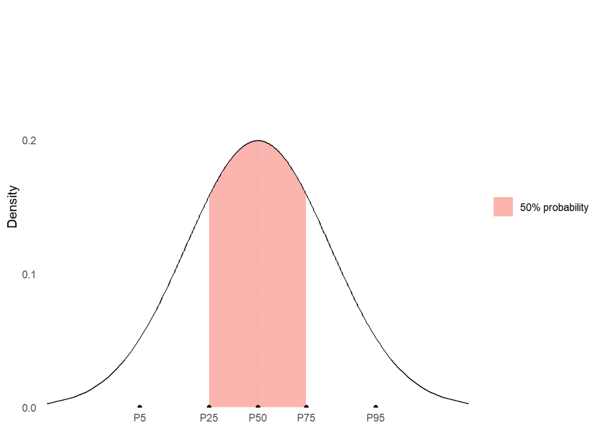

## Kvantiler illustrerade med en boxplot

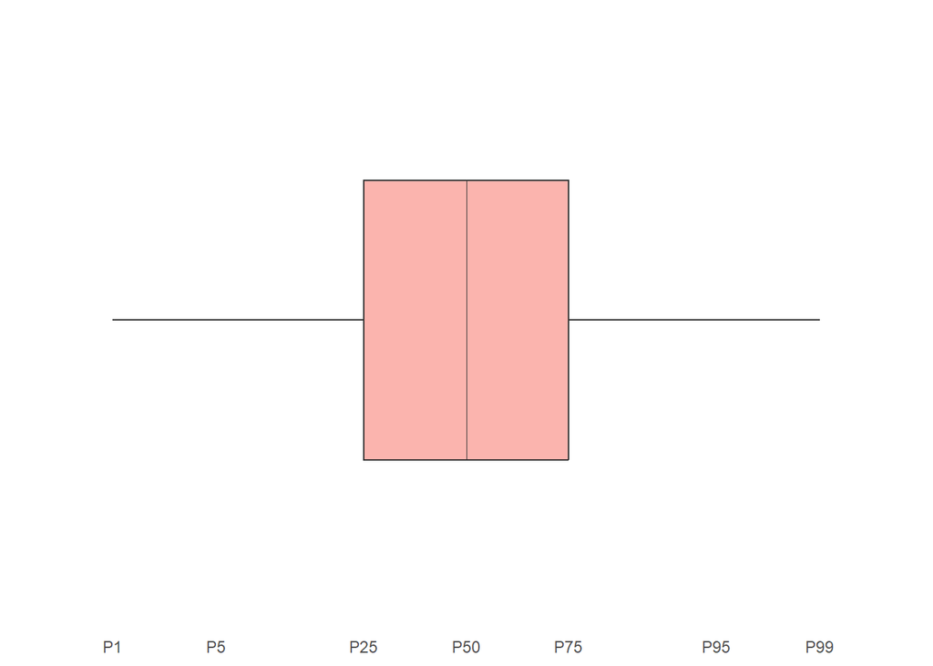

# Normalfördelningens kvantiler

Vi kommer använda kvantiler från en standardiserad normalfördelning för att skapa statistiska tester och konfidensintervall

Tabell-bladet innehåller några vanligt förekommande kvantiler

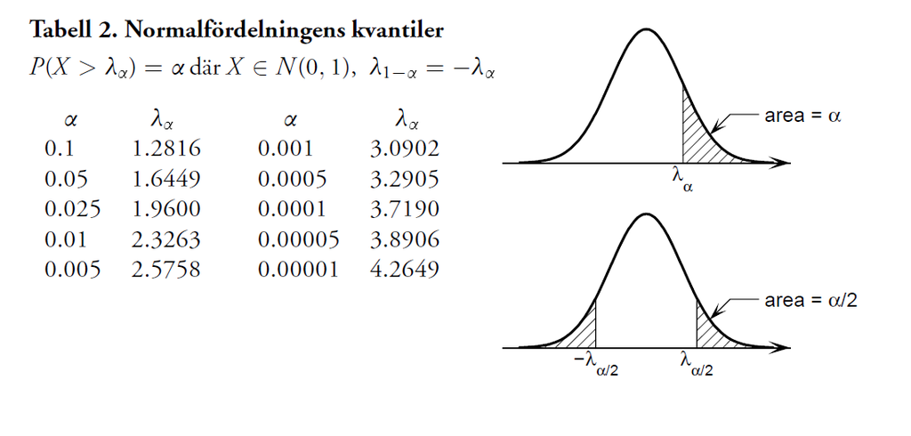

# Extrauppgifter

Låt $X \sim N(5,2)$

1. $P(X \leq 6) = P(\frac{X-5}{2} \leq \frac{6-5}{2}) = \Phi(\frac{1}{2})$

$$\begin{split} & P(1.8 < X < 7.2) = P(X < 7.2) - P(X \leq 1.8) = \\ & \Phi(\frac{7.2-5}{2})-\Phi(\frac{1.8-5}{2}) = \Phi(1.1) - \Phi(-1.6) = \\ & \Phi(1.1) - (1 - \Phi(1.6)) = 0.864 - (1 - 0.945) = 0.810 \end{split}$$

3. Hitta $a$ så att $P(X \leq a) = 0.05$

Låt $Z$ vara den standardiserade normalfördelningen $Z \sim N(0,1)$

Vi vet följande: $P(X \leq a) = P(Z \leq \frac{a-5}{2})$

Om vi kan hitta kvantilen för $Z$ så kan vi ta fram kvantilen för $X$

Från kvantiltabellen ser vi att $P(Z \leq z_{.05}) = 0.05$ när $z_{.05} = -1.645$

> utnyttja att $\lambda_{1-\alpha} = -\lambda_{\alpha}$

Då blir $x_{.05} = 5 + 2 \cdot z_{.05} = 5 + 2 \cdot (-1.645) = 1.71$